# Advancing Text Mining with R and quanteda

Cornelius Puschmann

January 30th, 2019

## Overview of this talk

1. Why quanteda?
2. Using quanteda
3. Applying dictionaries
4. Unsupervised machine learning
5. Supervised machine learning
6. Closing remarks

## Why quanteda?

- fully-featured
- great performance
- extensive [documentation](http://quanteda.io)
- regulary updates

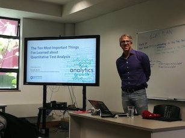

Kenneth Benoit, creator of quanteda

## Why quanteda?

- “competitors” include [tm](https://cran.r-project.org/web/packages/tm/vignettes/tm.pdf), [tidytext](https://www.tidytextmining.com/) and [korpus](https://cran.r-project.org/web/packages/koRpus/vignettes/koRpus_vignette.html)
- tidytext is very closely integrated with dplyr and well-documented
- tm has simpler grammer but slightly fewer features
- korpus is good for certain tasks (e.g. POS)
- other useful packages: [tidyverse](https://www.tidyverse.org/), [RTextTools](http://www.rtexttools.com/), [stm](https://www.structuraltopicmodel.com/)

## Using quanteda

Most analyses with quanteda onsist of three steps:

1. Import the data
2. Build a corpus
3. Calculate a DFM

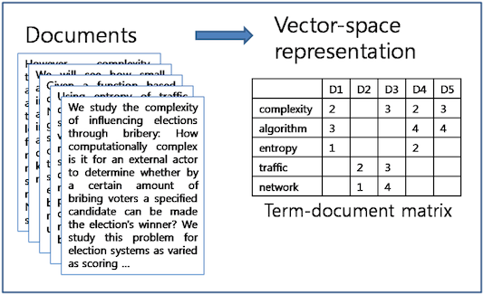

Model of a DTM.

## Using quanteda: Reading data

```r
sherlock <- readtext("data/sherlock/novels/[0-9]*.txt")
```

[output not shown]

```r
sherlock$doc_id <- str_sub(sherlock$doc_id, start = 4, end = -5)
mycorpus <- corpus(sherlock, docid_field = "doc_id")
docvars(mycorpus, "Textno") <- sprintf("%02d", 1:ndoc(mycorpus))
mycorpus
```

```
Corpus consisting of 12 documents and 1 docvar.
```

## Using quanteda: Generating corpus statistics

```r
mycorpus.stats <- summary(mycorpus)
mycorpus.stats$Text <- reorder(mycorpus.stats$Text, 1:ndoc(mycorpus), order = T)
mycorpus.stats
```

```
Corpus consisting of 12 documents:

                                  Text Types Tokens Sentences Textno
                  A Scandal in Bohemia  2145  10542       669     01
                 The Red-headed League  2087  11118       573     02
                    A Case of Identity  1750   8506       396     03
           The Boscombe Valley Mystery  2096  11499       636     04
                  The Five Orange Pips  1925   8879       475     05
          The Man with the Twisted Lip  2173  11160       586     06
   The Adventure of the Blue Carbuncle  1926   9651       552     07
    The Adventure of the Speckled Band  2232  11783       614     08
 The Adventure of the Engineer's Thumb  1968   9999       508     09
   The Adventure of the Noble Bachelor  1944   9987       540     10
    The Adventure of the Beryl Coronet  1991  11669       626     11
   The Adventure of the Copper Beeches  2110  12011       622     12

Source: /Users/cp/GDrive/Projekte/Advancing_Text_Mining_MZES/* on x86_64 by cp
Created: Wed Mar  6 14:26:15 2019
Notes:
```

## Using quanteda: What makes DFMs nifty

Things to remember about DFMS:

- a corpus is positional, a DFM is non-positional
- in most projects you want one corpus to contain all your data and generate many DFMs from that
- the rows of a DFM can contain any unit on which you can aggregates documents
- the columns of a DFM are any unit on which you can aggregate features

## Using quanteda: Calculating a DFM (1)

```r
mydfm <- dfm(mycorpus, remove_numbers = TRUE, remove_punct = TRUE, remove_symbols = TRUE, remove = stopwords("english"))
mydfm
```

```
Document-feature matrix of: 12 documents, 8,489 features (79.1% sparse).
```

```r
head(dfm_sort(mydfm, decreasing = TRUE, margin = "both"), n = 12, nf = 10)
```

```
Document-feature matrix of: 12 documents, 10 features (0.0% sparse).
12 x 10 sparse Matrix of class "dfm"
                                       features
docs                                    said upon holmes one man mr little now see may
  The Adventure of the Speckled Band      44   41     55  33  11  5     17  21  22  19
  The Adventure of the Copper Beeches     47   33     42  36  34 44     37  18  17  21
  The Boscombe Valley Mystery             37   42     43  31  41 24     25  16  24  19
  The Man with the Twisted Lip            28   54     28  36  30 20     21  27  18  15
  The Adventure of the Beryl Coronet      45   33     26  32  27 20     22  29  20  25
  The Red-headed League                   51   50     51  29  25 55     25  14  23   8
  A Scandal in Bohemia                    33   25     47  27  23  9     14  17  15  21
  The Adventure of the Engineer's Thumb   47   38     12  33  17 11     25  16  16   9
  The Adventure of the Noble Bachelor     33   29     34  31  10 17     26  16  16  18
  The Adventure of the Blue Carbuncle     43   38     34  38  37 17     24  33  27   7
  The Five Orange Pips                    32   47     25  29  19  3      5  12  16  24
  A Case of Identity                      45   35     46  17  16 50     28  15  15  11
```

## Using quanteda: Calculating a DFM (2)

```r
load("data/euspeech/euspeech.korpus.RData")
korpus.euspeech
```

```
Corpus consisting of 17,505 documents and 10 docvars.
```

```r
mydfm.eu <- dfm(korpus.euspeech, groups = "Typ")
mydfm.eu.prop <- dfm_weight(mydfm.eu, scheme = "prop")
head(dfm_sort(mydfm.eu.prop, decreasing = TRUE, margin = "both"), nf = 8)
```

```
Document-feature matrix of: 2 documents, 8 features (0.0% sparse).
2 x 8 sparse Matrix of class "dfm"
           features
docs           european        also     countri        need        year       europ      polici      govern
  Regierung 0.006177315 0.007775821 0.008114498 0.003875806 0.005878028 0.003943332 0.002321008 0.006384211
  EU        0.010959076 0.006602713 0.004304388 0.006419974 0.004401859 0.005781216 0.006610397 0.002485433
```

## Applying dictionaries: Defining an ad-hoc dictionary

```r
populism.liberalism.dict <- dictionary(list(populism = c("elit*", "consensus*", "undemocratic*", "referend*", "corrupt*", "propagand", "politici*", "*deceit*", "*deceiv*", "*betray*", "shame*", "scandal*", "truth*", "dishonest*", "establishm*", "ruling*"), liberalism = c("liber*", "free*", "indiv*", "open*", "law*", "rules", "order", "rights", "trade", "global", "inter*", "trans*", "minori*", "exchange", "market*")))
populism.liberalism.dict
```

```
Dictionary object with 2 key entries.
- [populism]:
  - elit*, consensus*, undemocratic*, referend*, corrupt*, propagand, politici*, *deceit*, *deceiv*, *betray*, shame*, scandal*, truth*, dishonest*, establishm*, ruling*
- [liberalism]:
  - liber*, free*, indiv*, open*, law*, rules, order, rights, trade, global, inter*, trans*, minori*, exchange, market*
```

## Applying dictionaries: Applying an ad-hoc dictionary

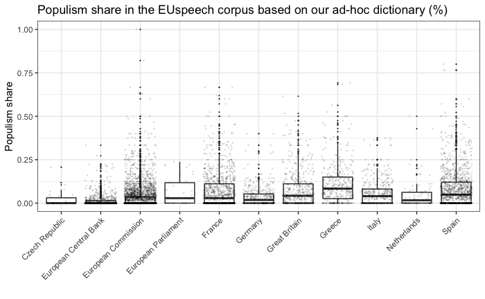

```r
mydfm.eu <- dfm(korpus.euspeech, dictionary = populism.liberalism.dict)
mydfm.eu.prop <- dfm_weight(mydfm.eu, scheme = "prop")
eu.poplib <- convert(mydfm.eu.prop, "data.frame") %>%
  bind_cols(korpus.euspeech.stats) %>%
  filter(length >= 1200, populism > 0 | liberalism > 0)
ggplot(eu.poplib, aes(country, populism)) + geom_boxplot(outlier.size = 0) + geom_jitter(aes(country,populism), position = position_jitter(width = 0.4, height = 0), alpha = 0.1, size = 0.2, show.legend = F) + theme(axis.text.x = element_text(angle = 45, vjust = 1, hjust = 1)) + xlab("") + ylab("Populism share") + ggtitle("Populism share in the EUspeech corpus based on our ad-hoc dictionary (%)")
```

## Applying dictionaries: Lexicoder Policy Agendas (PA)

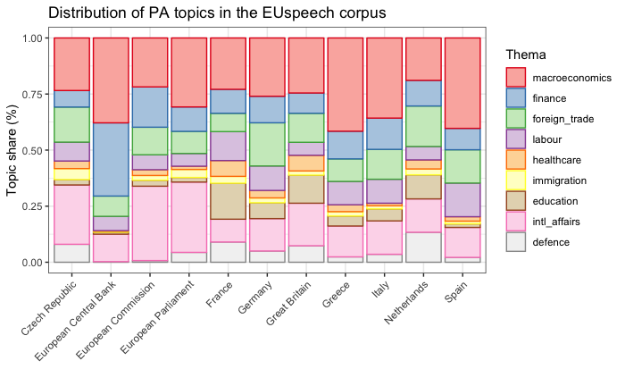

```r
load("dictionaries/policy_agendas_english.RData")
policyagendas.dict <- dictionary(dictLexic2Topics)
mydfm.eu.pa <- dfm(korpus.euspeech, groups = "country", dictionary = policyagendas.dict)
eu.topics.pa <- convert(mydfm.eu.pa, "data.frame") %>%
  rename(Land = document) %>%
  select(Land, macroeconomics, finance, foreign_trade, labour, healthcare, immigration, education, intl_affairs, defence) %>%
  gather(macroeconomics:defence, key = "Thema", value = "Anteil") %>%
  group_by(Land) %>%
  mutate(Anteil = Anteil/sum(Anteil)) %>%
  mutate(Thema = as_factor(Thema))
ggplot(eu.topics.pa, aes(Land, Anteil, colour = Thema, fill = Thema)) + geom_bar(stat="identity") + scale_colour_brewer(palette = "Set1") + scale_fill_brewer(palette = "Pastel1") + ggtitle("Distribution of PA topics in the EUspeech corpus") + xlab("") + ylab("Topic share (%)") + theme(axis.text.x = element_text(angle = 45, hjust = 1))
```

## Dictionaries: LIWC German (1)

```r
load("data/facebook/facebook.korpus.RData")
korpus.facebook
```

```
Corpus consisting of 20,000 documents and 3 docvars.
```

```r
texts(corpus_sample(corpus_subset(korpus.facebook, corpus == "populism"), size = 1))
```

```
                                                                                                                                 alternativefuerde3360
"Egal. Hauptsache es scheitert. Natürlich sind die Griechen schuld und nicht das Merkel. Und die zig Milliarden sind futsch. Deutschland = Blödland. "
```

```r
texts(corpus_sample(corpus_subset(korpus.facebook, corpus == "news"), size = 1))
```

```
                                                                                                                            zeit62
"so so, in London sehr ermutigend ich bewundere sie nicht. Mal sehen wer sie alle mitte oder ende nächsten Jahres noch bewundert!"
```

## Dictionaries: LIWC German (2)

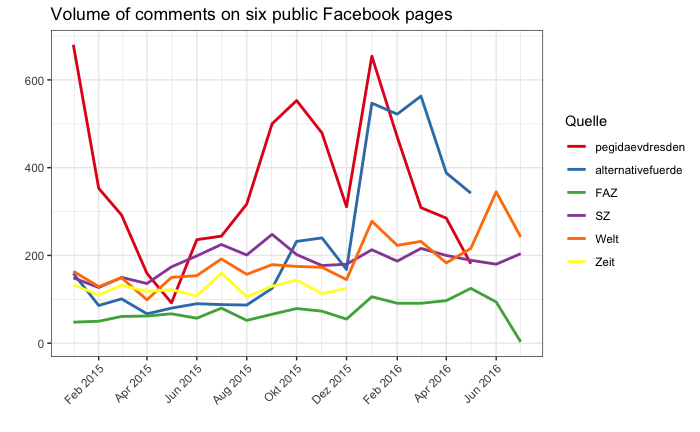

```r
facebook.aktivitaet <- korpus.facebook.stats %>%
  mutate(Quelle = factor(source, levels = c("pegidaevdresden", "alternativefuerde", "FAZ", "SZ", "Welt", "Zeit"))) %>%
  group_by(Datum = floor_date(created_time, "1 month"), Quelle) %>%
  summarise(Kommentare = n())
ggplot(facebook.aktivitaet, aes(as.Date(Datum), Kommentare, group = Quelle, col = Quelle)) + geom_line(size = 1) + scale_colour_brewer(palette = "Set1") + scale_x_date(date_breaks = "2 months", date_labels = "%b %Y") + ggtitle("Volume of comments on six public Facebook pages") + xlab("") + ylab("") + theme(axis.text.x = element_text(angle = 45, hjust = 1))
```

## Dictionaries: LIWC German (3)

```r
liwc.ger <- dictionary(file = "dictionaries/LIWC_German.dic", format = "LIWC")
```

[output not shown]

[output cut: 40 more lines]

```r
head(liwc.ger, 2)
```

```
Dictionary object with 2 key entries.
- [Pronoun]:
  - dein*, denen, deren, derer, dessen, dich, dir, du, er, es, euch, euer*, eure*, ich, ihm, ihn, ihnen, ihr, ihre, ihrem, ihren, ihrer, ihres, irgendei*, irgendet*, irgendj*, irgendwe*, jedermann*, jemand*, mein, meine, meinem, meinen, meiner, mich, mir, nichts, niemand*, sein*, sie, uns, unser, un…
- [I]:
  - ich, mein, meine, meinem, meinen, meiner, mich, mir
```

## Dictionaries: LIWC German (4)

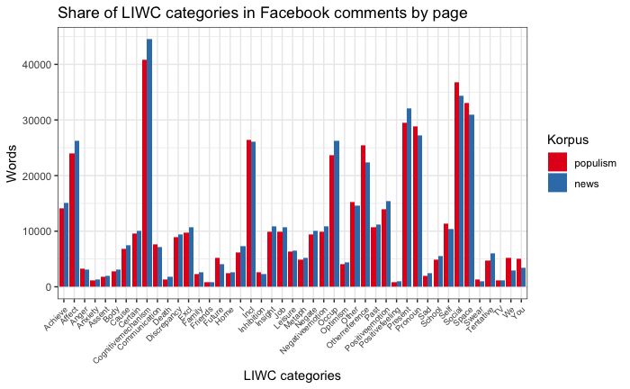

```r
mydfm.fb.liwc <- dfm(korpus.facebook, groups = "corpus", dictionary = liwc.ger)
liwc.shares <- convert(mydfm.fb.liwc, "data.frame") %>%
  rename(Korpus = document) %>%
  gather(key = Kategorie, value = Words, -Korpus) %>%
  filter(!Kategorie %in% c("Article", "Down", "Eat", "Fillers", "Grooming", "Humans", "Money", "Motion", "Music", "Nonfluency", "Numbers", "Physical", "Preps", "Relig", "Sex", "Sleep", "Sports", "Time", "Up")) %>%
  mutate(Korpus = factor(Korpus, levels = c("populism", "news")))
ggplot(liwc.shares, aes(Kategorie, Words, fill = Korpus)) + geom_bar(stat = "identity", position = position_dodge()) + scale_fill_brewer(palette = "Set1") + ggtitle("Share of LIWC categories in Facebook comments by page") + xlab("LIWC categories") + theme(axis.text.x = element_text(size = 7, angle = 45, hjust = 1))
```

## Unsupervised machine learning: Latent semantic analysis (LSA)

- LSA is a useful technique for aligning feature distributions to an n-dimensional space
- this is achieved via singular value decomposition (SVDS)
- LSA can (among other things) be used to compare similarity of documents/documents grouped by some variable

## Unsupervised machine learning: Latent semantic analysis (LSA)

```r
korpus.facebook.sample <- corpus_sample(korpus.facebook, size = 500)
mydfm.fb <- dfm(korpus.facebook.sample)
mylsa <- textmodel_lsa(mydfm.fb, nd = 10)
sources <- str_remove_all(rownames(mylsa$docs), "[0-9]")
sources.color <- rep("blue", times = length(sources))
sources.color[sources %in% c("alternativefuerde", "pegidaevdresden")] <- "red"
plot(mylsa$docs[,1:2], col = sources.color, pch = 19, xlab = "Dimension 1", ylab = "Dimension 2", main = "LSA dimensions by subcorpus")
plot(mylsa$docs[,2:3], col = sources.color, pch = 19, xlab = "Dimension 2", ylab = "Dimension 3", main = "LSA dimensions by subcorpus")
plot(mylsa$docs[,3:4], col = sources.color, pch = 19, xlab = "Dimension 3", ylab = "Dimension 4", main = "LSA dimensions by subcorpus")
plot(mylsa$docs[,4:5], col = sources.color, pch = 19, xlab = "Dimension 4", ylab = "Dimension 5", main = "LSA dimensions by subcorpus")
plot(mylsa$docs[,5:6], col = sources.color, pch = 19, xlab = "Dimension 5", ylab = "Dimension 6", main = "LSA dimensions by subcorpus")
plot(mylsa$docs[,6:7], col = sources.color, pch = 19, xlab = "Dimension 6", ylab = "Dimension 7", main = "LSA dimensions by subcorpus")
plot(mylsa$docs[,7:8], col = sources.color, pch = 19, xlab = "Dimension 7", ylab = "Dimension 8", main = "LSA dimensions by subcorpus")
plot(mylsa$docs[,8:9], col = sources.color, pch = 19, xlab = "Dimension 8", ylab = "Dimension 9", main = "LSA dimensions by subcorpus")
plot(mylsa$docs[,9:10], col = sources.color, pch = 19, xlab = "Dimension 9", ylab = "Dimension 10", main = "LSA dimensions by subcorpus")
```

[output not shown]

## Unsupervised machine learning: LDA (1)

```r
load("data/zeit/zeit.sample.korpus.RData")
as.data.frame(zeit.korpus.stats)
```

[output not shown]

## Unsupervised machine learning: LDA (2)

```r
mydfm.zeit <- dfm(zeit.korpus, remove_numbers = TRUE, remove_punct = TRUE, remove_symbols = TRUE, remove = stopwords("german"))
mydfm.zeit.trim <-  dfm_trim(mydfm.zeit, min_docfreq = 3, max_docfreq = 65)
mydfm.zeit.trim
```

[output not shown]

## Unsupervised machine learning: LDA (3)

```r
topic.count <- 15
dfm2topicmodels <- convert(mydfm.zeit.trim, to = "topicmodels")
lda.model <- LDA(dfm2topicmodels, topic.count)
lda.model
```

[output not shown]

## Unsupervised machine learning: LDA (4)

```r
as.data.frame(terms(lda.model, 6))
```

[output not shown]

## Unsupervised machine learning: LDA (5)

```r
lda.similarity <- as.data.frame(lda.model@beta) %>%
  scale() %>%
  dist(method = "euclidean") %>%
  hclust(method = "ward.D2")
par(mar = c(0, 4, 4, 2))
plot(lda.similarity, main = "LDA topic similarity by features", xlab = "", sub = "")
```

[output not shown]

## Unsupervised machine learning: STM (1)

- structured topic models (STM) are a popular alternative to standard LDA
- alternative initialization mechanism (“Spectral”)
- covariatees can be used in priors
- emphasis on a number of diagnostic functions integrated into the R package
- very useful: [stminsights](https://cran.r-project.org/web/packages/stminsights/vignettes/intro.html) package for visual exploration!

## Unsupervised machine learning: STM (2)

```r
load("data/un/un.stm.RData")
par(mar=c(0.5, 0.5, 0.5, 0.5))
cloud(modell.stm, topic = 1, scale = c(2.25,.5))
cloud(modell.stm, topic = 2, scale = c(2.25,.5))
cloud(modell.stm, topic = 7, scale = c(2.25,.5))
cloud(modell.stm, topic = 9, scale = c(2.25,.5))
plot(modell.stm, type = "summary", text.cex = 0.5, main = "STM topic shares", xlab = "Share estimation")
```

[output not shown]

## Supervised machine learning: NB classifier (1)

```r
load("data/nytimes/nyt.korpus.RData")
korpus.nyt
labels.cats <- scan("data/nytimes/majortopics2digits.txt", what = "char", sep = "\n", quiet = T)
labels.cats <- data.frame(Kategorie = as.character(1:length(labels.cats)), Label = labels.cats, stringsAsFactors = F)
labels.cats
```

[output not shown]

## Supervised machine learning: NB classifier (2)

```r
mydfm.nyt <- dfm(korpus.nyt, remove_numbers = TRUE, remove_punct = TRUE, remove = stopwords("english"))
mydfm.nyt
mydfm.nyt.trim <- dfm_trim(mydfm.nyt, min_docfreq = 0.0005, docfreq_type = "prop") # optional: min_count = 10
mydfm.nyt.trim
```

[output not shown]

## Supervised machine learning: NB classifier (3)

```r
modell.NB <- textmodel_nb(mydfm.nyt.trim, korpus.nyt.stats$Topic_2digit, prior = "docfreq")
head(as.character(predict(modell.NB)))
prop.table(table(predict(modell.NB) == korpus.nyt.stats$Topic_2digit))*100
prop.table(table(sample(predict(modell.NB)) == korpus.nyt.stats$Topic_2digit))*100
```

[output not shown]

## Supervised machine learning: NB classifier (4)

```r
model.NB.classification <- bind_cols(korpus.nyt.stats, Klassifikation = as.character(predict(modell.NB))) %>%
  mutate(Kategorie = as.character(Topic_2digit)) %>%
  mutate(RichtigKodiert = Klassifikation == Kategorie) %>%
  group_by(Kategorie, RichtigKodiert) %>%
  summarise(n = n()) %>%
  mutate(Anteil = n/sum(n)) %>%
  filter(RichtigKodiert == TRUE) %>%
  left_join(labels.cats, by = "Kategorie") %>%
  select(Kategorie, Label, n, Anteil)
ggplot(model.NB.classification, aes(Label, Anteil)) + geom_bar(stat = "identity") + geom_hline(yintercept = mean(model.NB.classification$Anteil), color = "blue") + ylim(0, 1) + ggtitle("Share of correctly classified texts in 26\ncontent categories with a Naive Bayes classifier") + xlab("") + ylab("") + coord_flip()
```

[output not shown]

## Supervised machine learning: RTextTools (1)

```r
container <- create_container(convert(mydfm.nyt.trim, to = "matrix"), korpus.nyt.stats$Topic_2digit, trainSize = 1:27775, testSize = 27776:30862, virgin = FALSE)
```

## Supervised machine learning: RTextTools (2)

```r
load("data/nytimes/nyt.modelle.RData")

# primäre Modelle
#modell.SVM <- train_model(container,"SVM")
#modell.GLMNET <- train_model(container,"GLMNET")
#modell.MAXENT <- train_model(container,"MAXENT")
#modell.SLDA <- train_model(container,"SLDA")

# weitere Modelle, funktionieren z.T. nicht
#modell.BOOSTING <- train_model(container,"BOOSTING")
#modell.BAGGING <- train_model(container,"BAGGING")
#modell.RF <- train_model(container,"RF")
#modell.NNET <- train_model(container,"NNET")
#modell.TREE <- train_model(container,"TREE")
```

## Supervised machine learning: RTextTools (3)

```r
SVM_CLASSIFY <- classify_model(container, modell.SVM)
GLMNET_CLASSIFY <- classify_model(container, modell.GLMNET)
MAXENT_CLASSIFY <- classify_model(container, modell.MAXENT)
SLDA_CLASSIFY <- classify_model(container, modell.SLDA)
#BOOSTING_CLASSIFY <- classify_model(container, modell.BOOSTING)
#BAGGING_CLASSIFY <- classify_model(container, modell.BAGGING)
#RF_CLASSIFY <- classify_model(container, modell.RF)
#NNET_CLASSIFY <- classify_model(container, modell.NNET)
#TREE_CLASSIFY <- classify_model(container, modell.TREE)
```

## Supervised machine learning: RTextTools (4)

```r
analytics <- create_analytics(container, cbind(SVM_CLASSIFY, GLMNET_CLASSIFY, MAXENT_CLASSIFY, SLDA_CLASSIFY))
summary(analytics)
```

[output not shown]

## Supervised machine learning: RTextTools (5)

```r
topic.codes <- scan("data/nytimes/majortopics2digits.txt", what = "char", sep = "\n", quiet = T)
topic.codes <- data.frame(category = as.factor(1:length(topic.codes)), category.label = topic.codes)
algdf <- data.frame(algorithm = str_split(colnames(analytics@algorithm_summary), "_", simplify = T)[,1], measure = factor(str_split(colnames(analytics@algorithm_summary), "_", simplify = T)[,2], levels = str_split(colnames(analytics@algorithm_summary), "_", simplify = T)[1:3,2]), category = factor(rep(rownames(analytics@algorithm_summary), each = ncol(analytics@algorithm_summary)), levels = rownames(analytics@algorithm_summary)), score = as.vector(t(analytics@algorithm_summary)))
algdf <- left_join(algdf, topic.codes, by = "category")
```

## Supervised machine learning: RTextTools (6)

```r
algdf <- filter(algdf, category.label %in% c("Civil Rights, Minority Issues, and Civil Liberties", "Education", "Environment", "Law, Crime, and Family Issues", "Macroeconomics", "Sports and Recreation"))
ggplot(algdf, aes(score, algorithm, color = measure, shape = measure)) + geom_point(size = 1.75) + facet_grid(category.label ~ ., switch = "y") + xlim(c(0,1)) + theme(strip.text.y = element_text(angle = 180)) + scale_colour_manual(values = c("lightblue", "lightgreen", "red")) + ggtitle("Precision, recall and f-score for four\nalgorithms measured across six\ncontent categories") + xlab("") + ylab("")
```

[output not shown]

## Closing remarks

- quanteda is useful for preparing data that is then subjected to UML/SML/other techniques
- combination with tidyverse leads to more transparent code
- a lot of useful areas I haven’t addressed (scaling models, POS tagging, named entities, word embeddings…)
- [validate, validate, validate](https://web.stanford.edu/~jgrimmer/tad2.pdf)